# Kira Plastinina

## *Hierachical clustering*

```r
d <- dist(normalized, method = "euclidean")
```

```r
# We then hierarchical clustering using the Ward's method
# ---
#
res.hc <- hclust(d, method = "ward.D2" )
```

```r
# We then hierarchical clustering using the Ward's method
# ---
#
res.hc <- hclust(d, method = "ward.D2" )
```

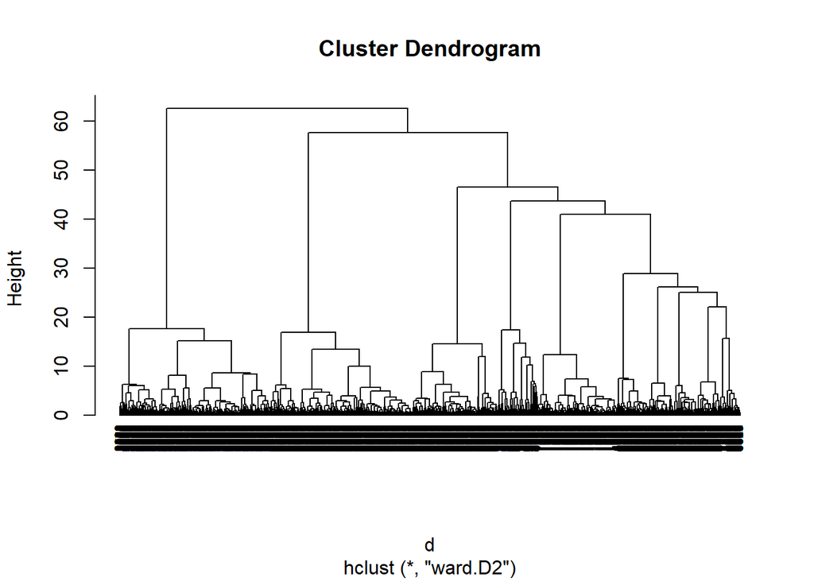

```r
options(repr.plot.width=35 ,repr.plot.height=20 )
plot(res.hc, cex = 0.6, hang = -1)
```

## *Challenge the Solution*

*K-means clustering*

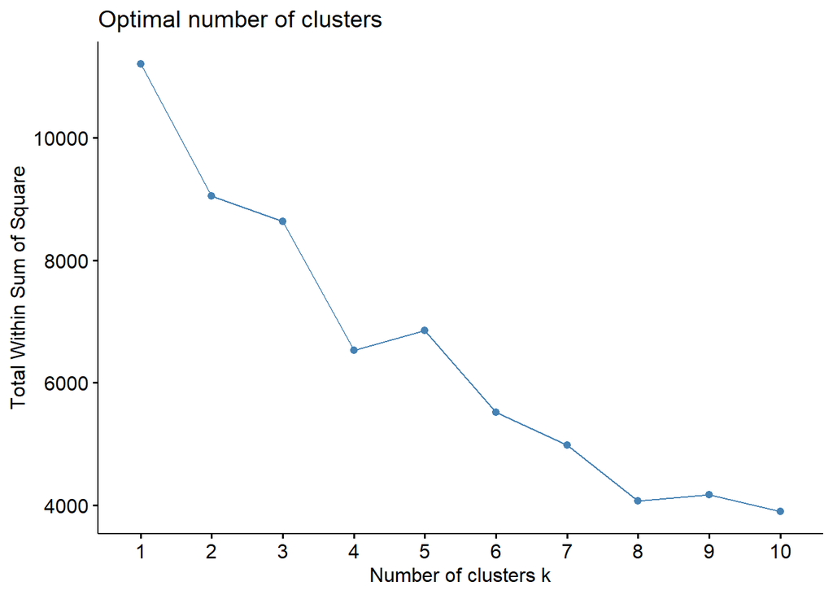

```r
#Determining optimal number of Clusters (Cluster elbow method)
fviz_nbclust(normalized, FUN = kmeans, method = "wss")
```

```r
result1<- kmeans(normalized,4) #aplly k-means algorithm with no. of centroids(k)=4
```

```r
result1$size  # gives no. of records in each cluster
```

```
## [1] 2352 2192 3104 1308
```

```r
result1$centers # gives value of cluster center datapoint
```

```
##   administrative administrative_duration informational informational_duration
## 1     0.09148243              0.03579266    0.02867241             0.01184782
## 2     0.09612606              0.03757100    0.03085082             0.01396854
## 3     0.10954951              0.04131473    0.02980026             0.01403486
## 4     0.09288991              0.03618403    0.02962538             0.01425833
##   productrelated productrelated_duration bouncerates exitrates pagevalues
## 1      0.1246015               0.2847000  0.12745545 0.2127895 0.01860710
## 2      0.1394717               0.3214738  0.10172915 0.1867882 0.02131011
## 3      0.1157150               0.2564683  0.10064552 0.1849474 0.01648200
## 4      0.1161702               0.2752108  0.09792998 0.1864491 0.02171942
##    specialday  monthAug monthDec   monthFeb  monthJul  monthJune  monthMar
## 1 0.204336735 0.0000000        0 0.00000000 0.0000000 0.00000000 0.0000000
## 2 0.000000000 0.0000000        0 0.00000000 0.0000000 0.00000000 0.0000000
## 3 0.008118557 0.1156572        0 0.03286082 0.1127577 0.07313144 0.3991624
## 4 0.000000000 0.0000000        1 0.00000000 0.0000000 0.00000000 0.0000000
##   monthMay monthNov  monthOct  monthSep operatingsystems   browser    region
## 1        1        0 0.0000000 0.0000000        0.1624150 0.1152920 0.2727997
## 2        0        1 0.0000000 0.0000000        0.1610401 0.1032543 0.2627737
## 3        0        0 0.1478737 0.1185567        0.1536267 0.1072541 0.2685245
## 4        0        0 0.0000000 0.0000000        0.1768239 0.1298420 0.2931957
##   traffictype
## 1   0.1802721
## 2   0.1908855
## 3   0.1304768
## 4   0.1559231
```

```r
result1$cluster #gives cluster vector showing the custer where
```

[output not shown]

[output cut: 1105 more lines]

```r
result1$betweenss / result$totss
```

```
## [1] 0.4513823
```

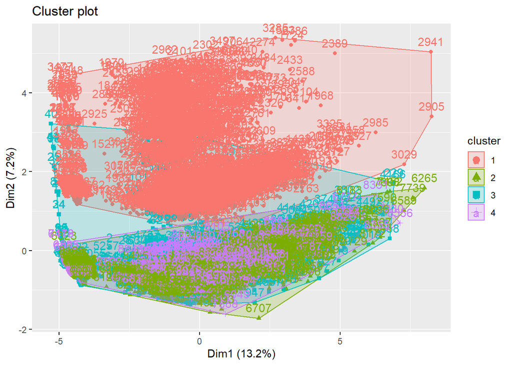

```r
fviz_cluster(result1, normalized)
```

```r
table(result1$cluster, shoppers1$revenue)
```

```
##
##     FALSE TRUE
##   1  2038  314
##   2  1674  518
##   3  2625  479
##   4  1126  182
```

*Hierarchical Clustering*

```r
#calculate manhattan distance

data2di <- dist(normalized, method = "man")
```

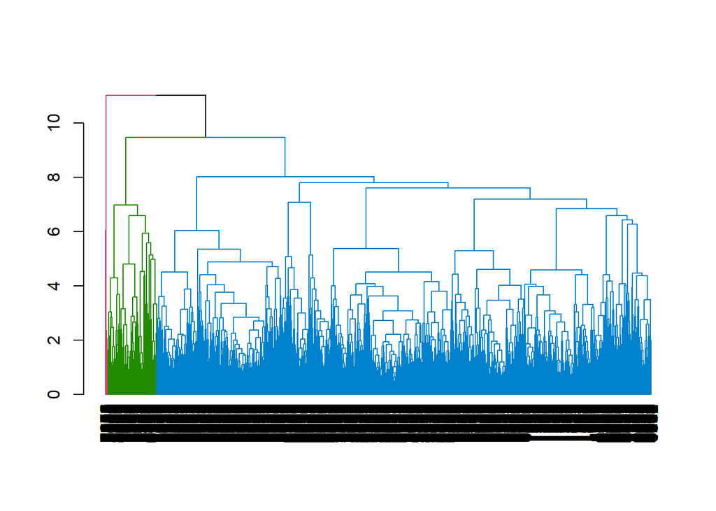

```r
## We then hierarchical clustering using the complete method
data2hc <- hclust(data2di, method = "complete")
data2as <- cutree(data2hc, k = 3)

dend_data <- as.dendrogram(data2hc)
cc <- color_branches(dend_data, k=3)

options(repr.plot.width=40 ,repr.plot.height=20 )
plot(cc)
```

```
##   cluster size ave.sil.width
## 1       1  801          0.29
## 2       2 8114          0.27
## 3       3   41          0.70
```

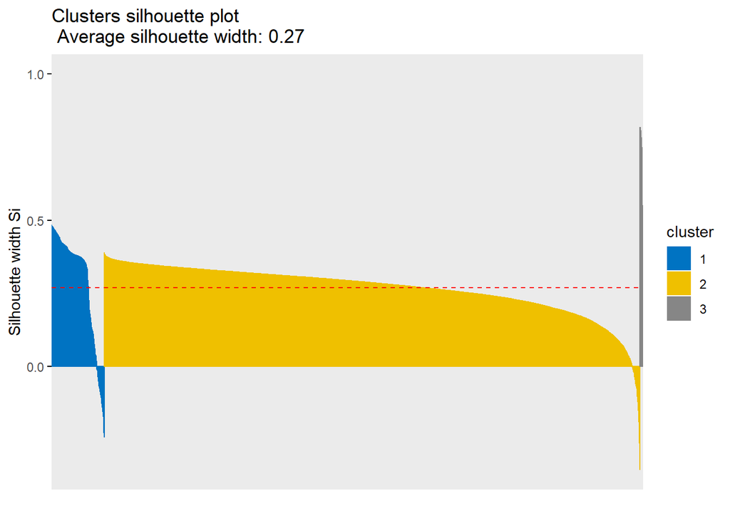

```r
sil <- silhouette(data2as, data2di)

fviz_silhouette(sil,palette= "jco",ggtheme = theme_minimal())
```

We could also do PCA (Principal component analysis) for dimensional reduction and then do k-means and hierarchical clustering

*Summary*

k-means may be computationally faster than hierarchical clustering if the number of clusters is small.

Hierarchical clustering is also easy to implement. Required less codes to implement

On the other hand, the result of a hierarchical clustering is a structure that is more informative and interpretable than the unstructured set of flat clusters returned by k-means. Therefore, it is easier to determine the optimal number of clusters by looking at the dendrogram of a hierarchical clustering than trying to predict this optimal number in advance in case of k-means.

High space and time complexity for Hierarchical clustering. Hence this clustering algorithm is difficult to use when we have huge data.

## *Follow up Questions*

Are there more models to improve the getting of characteristics